# Scalable Data Analysis with Spark and Microsoft R Server

October 25th, 2016

## Scalable Data Analysis with R and Spark

## Unpacking the Title

- Scalable - should be able to accommodate large datasets
  - \[p > n\]
  - streaming datasets
  - generally large datasets where you want to do some inference
- R and Spark
  - R is great at statistical modeling, visualization and inference
  - R is also lazy, and functional
  - Let's reuse the API

## Background

- Studied statistics and machine learning at the University of Toronto
- Joined Microsoft through the Revolution Analytics acquistion last year
- Have used R for about 7 years now
- Hadoop for 2.5 years
- Spark for 1.5 years

## Strengths of R

### Where R Succeeds

- Expressive
- Open source
- Extendable – nearly 10,000 packages with functions to use, and that list continues to grow
- Focused on statistics and machine learning – utilized by academics and practitioners
- Advanced data structures and graphical capabilities
- Large user community, academics and industry
- It is designed by statisticians

## Weaknesses of R

### Where R Falls Short

- It is designed by statisticians
- Inefficient at element-by-element computations
- May make large demands on system resources, namely memory
- Data capacity limited by memory
- Single-threaded

## Microsoft R Server - Scalable R

### WODA - Reusable API

- Breaks R's memory shackles by using external data frames (XDFs) and bridges to distributed systems (Spark, HadoopMR, Teradata)
- One of the core principles behind Microsoft R Server is the WODA framework
  - WODA – write once deploy anywhere
  - Encourages API reuse
- Provides seamless transition from a local environment to a cluster environment
- Don't want to rewrite the entire code-base in Java/Scala
- Deployment should be possible within seconds

## Microsoft R Server

### Components

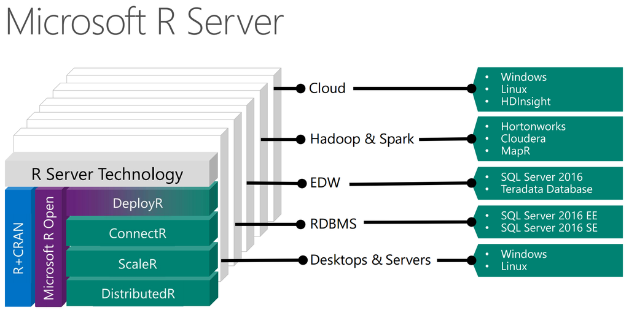

## R APIs for Spark - A Tale of Three APIs

## The aRt of Being Lazy

### Lazy Evaluation in R

[figure not shown]

- R, like it's inspiration, Scheme, is a *functional* programming language
- R evaluates lazily, delaying evaluation until necessary, which can make it very flexible
- R has a high memory footprint, and can easily lead to crashes if you aren't careful

## R APIs for Spark

### `RxSpark`

- Allows the distribution of local R code into spark applications
- The only abstractions are those of the `RevoScaleR` package
  - data resides as distributed on-disk objects (`xdfd`'s)
  - Functions and data transformations are provided by traditional R objects
- Each `RevoScaleR` function invokes it's own Spark applications and converts XDFDs into RDDs/DataFrames
  - application persists for the duration of the job to avoid JVM creation overhead
  - for multi-iteration jobs, data is cached
  - no need for the developer to write any Spark code
- Available through Azure HDInsight Clusters
  - currently utilizing Spark 1.6
- User defined functions can be applied at the data partition level using `rxExec`

## R APIs for Spark

### `SparkR`

- The standard R API for Spark since 1.4 (MLLib support started in 1.5)
- R package provides functions that invoke functions directly on the JVM
  - Uses a RPC server and provides JVM wrappers
- `DataFrame` support is inspired by the `dplyr` package
  - tries to emulate `dplyr` syntax, but doesn't use NSE
  - `dplyr`: `taxi %>% group_by(pickup_nhood) %>%` `summarise(ave_delay = mean(pickup_delay))`
  - `SparkR`: `taxi %>% group_by(taxi$pickup_nhood) %>%` `summarise(ave_delay = mean(taxi$pickup_delay))`
- Limited ML: `glm`, `naive-bayes`, and `kmeans`
- Spark 2.0: support for custom UDFs using `dapply` and `gapply`
  - each partition must fit into an R process on the worker node

## R APIs for Spark

### Masking with `dplyr`

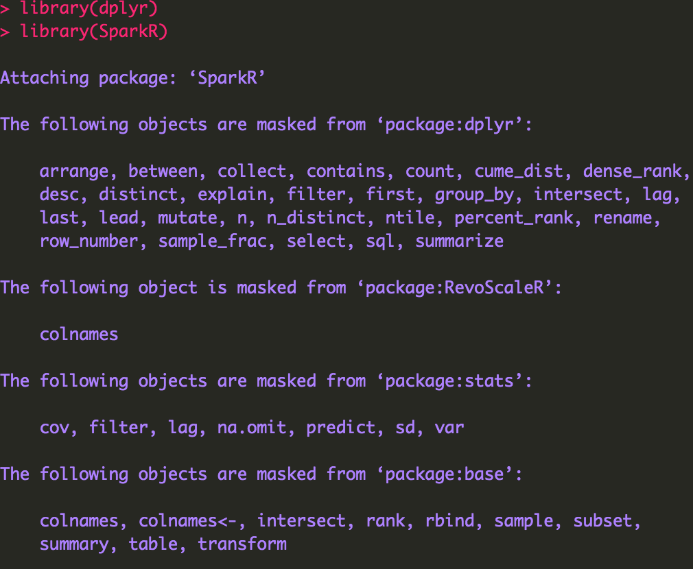

## R APIs for Spark

### `sparklyr`

- Turns out `dplyr` already has a SQL backend
- Since all Spark DataFrame operations are conducted at the Spark SQL level, utilize `dplyr`'s SQL backend rather than JVM wrappers
- 100% support for `dplyr` SQL inside of Spark, including NSE:
  - `_lyr`: `taxi %>% group_by(pickup_nhood) %>%` `summarise(ave_delay = mean(pickup_delay))`
- Full support for all `SparkML`
- No UDF support yet

## R APIs for Spark

### `sparklyr` relies on RPC layer provided by `sparkapi`

- `sparklyr` is meant to be the DSL, providing easy data manipulation with `dplyr` and ML analogously to `stats` and other modeling packages
- The core RPC layer is not inside of `sparklyr`
- `sparkapi` provides the core R to Java RPC bridge publicly, and provides a simple extension mechanism to call arbitrary Spark APIs packages
  - e.g., extensions to connect o [H20 Sparkling Water](http://spark.rstudio.com/h2o.html) with `sparkapi` now exist

## Azure HDInsight

### Full Managed Hadoop/Spark on the Cloud

- With Azure HDInsight, you don't have to choose
- Can use any combination of the APIs for your data science application
- Focus less on optimizing code, rewriting your functions, and focus more on developing applications

## Data Manipulation Examples

## `sparklyr`

### Tidy Data Manipulation Using `dplyr` syntax

- For data scientists comfortable with R, using `sparklyr` requires no prior Spark knowledge
- `dplyr` statements are converted to SQL statements, sent to Catalyst and optimized

## Import Into Spark DataFrames

```r
origins <- file.path("wasb://mrs-spark@alizaidi.blob.core.windows.net",
                     "user/RevoShare/alizaidi/Freddie/Acquisition")
library(sparklyr)
sc <- spark_connect("yarn-client")
freddie_origins <- spark_read_csv(sc,
                                  path = origins,
                                  name = 'freddie_origins',
                                  header = FALSE,
                                  delimiter = "|"
                                  )
```

## Using `dplyr`

- Now it's a Spark DataFrame
- It is also of class `tbl_sql`, so all `dplyr` methods are converted to `Spark SQL` statements and run on the spark application defined through the spark context `sc`

```r
class(freddie_origins)
```

```
## [1] "tbl_spark" "tbl_sql"   "tbl_lazy"  "tbl"
```

```r
library(dplyr)
freddie_origins %>% head
```

```
## Source:   query [?? x 25]
## Database: spark connection master=yarn-client app=sparklyr local=FALSE
##
##      V1     V2    V3     V4    V5    V6    V7    V8    V9   V10    V11
##   <chr>  <int> <chr>  <int> <int> <chr> <int> <chr> <dbl> <chr>  <int>
## 1   751 199910     N 202909    NA   000     1     O    71    20 180000
## 2   733 199909     N 202908 29540   000     1     O    51       116000
## 3   755 199905     N 202904 29540    30     1     O    95    38 138000
## 4   669 200206     N 202901    NA   000     1     O    80    33 162000
## 5   732 199904     N 202903 17140   000     1     O    25    10  53000
## 6   715 199904     N 202903 17140   000     1     O    67    35  91000
## # ... with 14 more variables: V12 <int>, V13 <dbl>, V14 <chr>, V15 <chr>,
## #   V16 <chr>, V17 <chr>, V18 <chr>, V19 <int>, V20 <chr>, V21 <chr>,
## #   V22 <int>, V23 <int>, V24 <chr>, V25 <chr>
```

## Renaming Columns

```r
freddie_rename <- freddie_origins %>% rename(
                          credit_score = V1,
                          first_payment = V2,
                          first_home = V3,
                          maturity = V4,
                          msa = V5,
                          mi_perc = V6,
                          num_units = V7,
                          occ_status = V8,
                          cltv = V9,
                          dti = V10,
                          upb = V11,
                          ltv = V12,
                          orig_rate = V13,
                          channel = V14,
                          ppm = V15,
                          prod_type = V16,
                          state = V17,
                          prop_type = V18,
                          post_code = V19,
                          loan_number = V20,
                          loan_purpose = V21,
                          orig_term = V22,
                          num_borrowers = V23,
                          seller = V24,
                          servicer = V25
                          )
freddie_rename %>% head
```

```
## Source:   query [?? x 25]
## Database: spark connection master=yarn-client app=sparklyr local=FALSE
##
##   credit_score first_payment first_home maturity   msa mi_perc num_units
##          <chr>         <int>      <chr>    <int> <int>   <chr>     <int>
## 1          751        199910          N   202909    NA     000         1
## 2          733        199909          N   202908 29540     000         1
## 3          755        199905          N   202904 29540      30         1
## 4          669        200206          N   202901    NA     000         1
## 5          732        199904          N   202903 17140     000         1
## 6          715        199904          N   202903 17140     000         1
## # ... with 18 more variables: occ_status <chr>, cltv <dbl>, dti <chr>,
## #   upb <int>, ltv <int>, orig_rate <dbl>, channel <chr>, ppm <chr>,
## #   prod_type <chr>, state <chr>, prop_type <chr>, post_code <int>,
## #   loan_number <chr>, loan_purpose <chr>, orig_term <int>,
## #   num_borrowers <int>, seller <chr>, servicer <chr>
```

## Create Date Fields

The origination date is buried inside the loan number field. We will pick it out by indexing the loan number substring:

```r
freddie_rename %>% select(loan_number)
```

```
## Source:   query [?? x 1]
## Database: spark connection master=yarn-client app=sparklyr local=FALSE
##
##     loan_number
##           <chr>
## 1  F199Q1000001
## 2  F199Q1000002
## 3  F199Q1000003
## 4  F199Q1000004
## 5  F199Q1000005
## 6  F199Q1000006
## 7  F199Q1000007
## 8  F199Q1000008
## 9  F199Q1000009
## 10 F199Q1000010
## # ... with more rows
```

## Substring Operations

```r
freddie_rename <- freddie_rename %>%
  mutate(orig_date = substr(loan_number, 3, 4),
         year = as.numeric(substr(loan_number, 3, 2)))

freddie <- freddie_rename %>%
  mutate(orig_year = paste0(ifelse(year < 10, "200",
                                   ifelse(year > 16, "19",
                                          "20")), year))

freddie <- freddie %>%
  mutate(orig_year = substr(orig_year, 1, 4))

freddie %>% head
```

```
## Source:   query [?? x 28]
## Database: spark connection master=yarn-client app=sparklyr local=FALSE
##
##   credit_score first_payment first_home maturity   msa mi_perc num_units
##          <chr>         <int>      <chr>    <int> <int>   <chr>     <int>
## 1          751        199910          N   202909    NA     000         1
## 2          733        199909          N   202908 29540     000         1
## 3          755        199905          N   202904 29540      30         1
## 4          669        200206          N   202901    NA     000         1
## 5          732        199904          N   202903 17140     000         1
## 6          715        199904          N   202903 17140     000         1
## # ... with 21 more variables: occ_status <chr>, cltv <dbl>, dti <chr>,
## #   upb <int>, ltv <int>, orig_rate <dbl>, channel <chr>, ppm <chr>,
## #   prod_type <chr>, state <chr>, prop_type <chr>, post_code <int>,
## #   loan_number <chr>, loan_purpose <chr>, orig_term <int>,
## #   num_borrowers <int>, seller <chr>, servicer <chr>, orig_date <chr>,
## #   year <dbl>, orig_year <chr>
```

## Calculate Average Credit Score by Year

```r
fico_year <- freddie %>% group_by(orig_year, state) %>%
  summarise(ave_fico = mean(credit_score)) %>% collect
fico_year %>% head
```

```
## Source: local data frame [6 x 3]
## Groups: orig_year [6]
##
##   orig_year state ave_fico
##       <chr> <chr>    <dbl>
## 1      2008    NM 730.7395
## 2      2012    WI 769.2008
## 3      2015    MI 752.5942
## 4      2014    AR 750.9074
## 5      2011    KS 763.1039
## 6      2006    WI 728.6378
```

## Summarize In a Function

```r
year_state_sum <- function(val = "credit_score") {

  library(lazyeval)

  year_state <- freddie %>% group_by(orig_year, state) %>%
    summarise_(sum_val = interp(~mean(var), var = as.name(val)))

  year_state <- year_state %>% collect

  names(year_state)[3] <- paste0("ave_", val)

  return(year_state)

}
```

## Plot

```r
library(rMaps)
year_state_sum("dti") %>%
  mutate(year = as.numeric(orig_year)) %>%
  rMaps::ichoropleth(ave_dti ~ state, data = .,
                     animate = "year",
                     geographyConfig = list(popupTemplate = "#!function(geo, data) {
                                         return '<div class=\"hoverinfo\"><strong>'+
                                         data.state + '<br>' + 'Average DTI in  '+ data.year + ': ' +
                                         data.ave_dti.toFixed(2)+
                                         '</strong></div>';}!#")) -> state_fico

state_fico$save("StateMapDTI.html", cdn = T)
```

## Machine Learning with `RxSpark`

## Predictive Models in the `RevoScaleR` package

[figure not shown]

## Building Machine Learning Pipelines

### Functional Decompositions

```r
estimate_model <- function(xdf_data = freddie[["train"]],
                           form = make_form(xdf_data, depVar = "default_flag"),
                           model = rxLogit, ...) {

  rx_model <- model(form, data = xdf_data, ...)

  return(rx_model)


}
```

## Executing Our Models In Parallel

### Functionals

```r
computeContext <- RxSpark(consoleOutput=TRUE,
                          nameNode=myNameNode,
                          port=myPort,
                          executorCores=6,
                          executorMem = "10g",
                          executorOverheadMem = "5g",
                          persistentRun = TRUE

rxSetComputeContext(computeContext)

models <- list(rxLogit, rxDTree, rxDForest, rxBTrees)
trained_models <- rxExec(estimate_model, model = rxElemArg(models))
```

## Scoring the Models

```r
default_pred <- function(model = default_model_gbm) {

  scored_xdf <- rxPredict(model,
                          mort_split$validate,
                          "scored.xdf")


  return(scored_xdf)
}
```

## Model Results

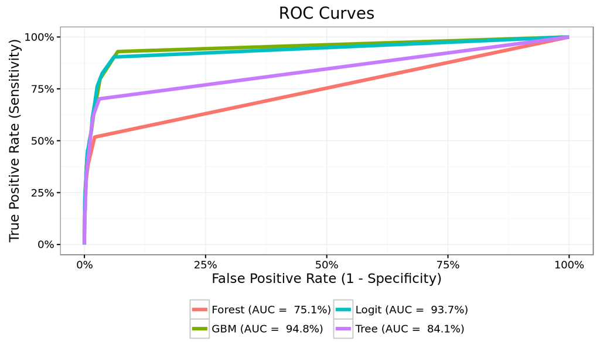

## What's Next

## Next Steps

- Sharing of Spark Contexts
  - currently, each of these APIs use their own backend to create Spark Sessions/Contexts, and cannot share objects across
- `RxSpark` will allow for using Spark DataFrames directly, and to share Spark sessions with other APIs
- Addition of new models and transformers in RevoScaleR

## Thank You!

## Resources

- https://github.com/akzaidi/R-cadence/tree/master/Spark
- https://bookdown.org/alizaidi/mrs-spark-ml/
- http://spark.rstudio.com/